# Descriptive statistics

IBRAHIM KASSOUM Habibou

2024-07-19

## Importing library

## Analysis of missing values and migration or attrition by region and migration.

### Splitted hh

The split households are on average:

- Bigger in terms of size.
- Less likely to be female-headed.
- Have older heads.
- Have less educated heads.
- Have more female members.
- Have more children under five.
- Have more teenagers.
- Have more adults.
- Have more female adults and teenagers.
- Have more teenage adults.

|  | **Don’t split**, N = 6,054<sup>1</sup> | **Split**, N = 449<sup>1</sup> | **p-value**<sup>2</sup> | **Overall**, N = 6,503<sup>1</sup> |
| --- | --- | --- | --- | --- |
| Hh. size | 4.08 (1.50) | 5.81 (2.27) | <0.001 | 4.20 (1.63) |
| Affected upazila (Yes=1, No=0) | 1,668 (28%) | 112 (25%) | 0.2 | 1,780 (27%) |
| Hh. head rlgn |  |  | 0.15 |  |
| Christian | 13 (0.2%) | 2 (0.4%) |  | 15 (0.2%) |
| Hindu | 699 (12%) | 41 (9.1%) |  | 740 (11%) |
| Muslim | 5,342 (88%) | 406 (90%) |  | 5,748 (88%) |
| Hh. head ethnc |  |  | 0.7 |  |
| Bangali | 6,035 (100%) | 449 (100%) |  | 6,484 (100%) |
| Bihari | 3 (<0.1%) | 0 (0%) |  | 3 (<0.1%) |
| Tribal | 16 (0.3%) | 0 (0%) |  | 16 (0.2%) |
| Hh. head sex |  |  | <0.001 |  |
| female | 1,103 (18%) | 51 (11%) |  | 1,154 (18%) |
| male | 4,951 (82%) | 398 (89%) |  | 5,349 (82%) |
| Hh. head age | 43.69 (13.83) | 50.64 (14.41) | <0.001 | 44.17 (13.98) |
| Hh. head mrtl stts |  |  | 0.2 |  |
| divorced | 16 (0.3%) | 1 (0.2%) |  | 17 (0.3%) |
| married | 5,503 (91%) | 396 (88%) |  | 5,899 (91%) |
| separated/deserted | 42 (0.7%) | 2 (0.4%) |  | 44 (0.7%) |
| unmarried (never married) | 112 (1.9%) | 14 (3.1%) |  | 126 (1.9%) |
| widow/widower | 381 (6.3%) | 36 (8.0%) |  | 417 (6.4%) |
| Hh. head ltrc |  |  | <0.001 |  |
| can read only | 5 (<0.1%) | 0 (0%) |  | 5 (<0.1%) |
| can read and write | 2,893 (48%) | 165 (37%) |  | 3,058 (47%) |
| can sign only | 1,804 (30%) | 156 (35%) |  | 1,960 (30%) |
| cannot read and write | 1,352 (22%) | 128 (29%) |  | 1,480 (23%) |
| Hh. head edctn |  |  | 0.035 |  |
| ba/bsc honors/fazil | 8 (0.1%) | 0 (0%) |  | 8 (0.1%) |
| ba/bsc pass/fazil | 63 (1.0%) | 4 (0.9%) |  | 67 (1.0%) |
| completed class 2 | 187 (3.1%) | 9 (2.0%) |  | 196 (3.0%) |
| completed class 3 | 176 (2.9%) | 12 (2.7%) |  | 188 (2.9%) |
| completed class 4 | 298 (4.9%) | 15 (3.3%) |  | 313 (4.8%) |
| completed class 5 | 762 (13%) | 53 (12%) |  | 815 (13%) |
| completed class 6 | 163 (2.7%) | 12 (2.7%) |  | 175 (2.7%) |
| completed class 7 | 201 (3.3%) | 11 (2.4%) |  | 212 (3.3%) |
| completed class 8 | 344 (5.7%) | 22 (4.9%) |  | 366 (5.6%) |
| completed class 9 | 401 (6.6%) | 22 (4.9%) |  | 423 (6.5%) |
| completed class i | 64 (1.1%) | 3 (0.7%) |  | 67 (1.0%) |
| completed hsc/alim | 120 (2.0%) | 5 (1.1%) |  | 125 (1.9%) |
| completed ssc/dakhil | 288 (4.8%) | 9 (2.0%) |  | 297 (4.6%) |
| diploma engineer | 3 (<0.1%) | 0 (0%) |  | 3 (<0.1%) |
| ma/msc and above/kamil | 27 (0.4%) | 1 (0.2%) |  | 28 (0.4%) |
| never attended school | 2,892 (48%) | 264 (59%) |  | 3,156 (49%) |
| other | 1 (<0.1%) | 0 (0%) |  | 1 (<0.1%) |
| preschool (mosque based) | 1 (<0.1%) | 0 (0%) |  | 1 (<0.1%) |
| preschool class (general) | 2 (<0.1%) | 1 (0.2%) |  | 3 (<0.1%) |
| reads in class i | 51 (0.8%) | 6 (1.3%) |  | 57 (0.9%) |
| ssc candidate | 2 (<0.1%) | 0 (0%) |  | 2 (<0.1%) |
| Hh. head stts |  |  |  |  |
| permanent(r1) | 6,054 (100%) | 449 (100%) |  | 6,503 (100%) |
| Hh. nbr fml | 2.15 (1.06) | 2.84 (1.49) | <0.001 | 2.20 (1.11) |
| Hh. nbr undrfv | 0.44 (0.61) | 0.56 (0.70) | <0.001 | 0.45 (0.62) |
| Hh. nbr yng child (5-10) | 0.54 (0.68) | 0.47 (0.78) | 0.078 | 0.54 (0.69) |
| Hh. nbr tngr (10-20) | 0.86 (0.95) | 1.22 (1.08) | <0.001 | 0.89 (0.97) |
| Hh. nbr adlts (20-65) | 2.01 (0.81) | 3.16 (1.29) | <0.001 | 2.09 (0.90) |
| Hh. nbr female undrfv | 0.22 (0.46) | 0.25 (0.52) | 0.2 | 0.23 (0.47) |
| Hh. fml yng child (5-10) | 0.27 (0.50) | 0.24 (0.51) | 0.2 | 0.27 (0.50) |
| Hh. fml tngr (10-20) | 0.44 (0.65) | 0.57 (0.71) | <0.001 | 0.44 (0.66) |
| Hh. fml adlts (20-65) | 1.12 (0.46) | 1.63 (0.78) | <0.001 | 1.16 (0.50) |

<sup>1</sup> Mean (SD); n (%)  
<sup>2</sup> Welch Two Sample t-test; Fisher’s Exact Test for Count Data; Fisher’s Exact Test for Count Data with simulated p-value (based on 2000 replicates)

```
##
## Splitted hh. characteristics
## =======================================================================
##                                                 Dependent variable:
##                                             ---------------------------
##                                                   hh_split_r2_r3
##                                               Binary for splitted hh.
## -----------------------------------------------------------------------
## hhm_sexmale                                          -0.11***
##                                                       (0.01)
##
## hhm_age                                               0.0004
##                                                      (0.0003)
##
## hh_size                                               0.11***
##                                                       (0.01)
##
## marital_status_hhmmarried                              0.04
##                                                       (0.06)
##
## marital_status_hhmseparated/deserted                   0.03
##                                                       (0.07)
##
## marital_status_hhmunmarried (never married)            0.11*
##                                                       (0.06)
##
## marital_status_hhmwidow/widower                        0.07
##                                                       (0.06)
##
## literacy_hhmcan read and write                         0.09
##                                                       (0.10)
##
## literacy_hhmcan sign only                              0.10
##                                                       (0.11)
##
## literacy_hhmcannot read and write                      0.10
##                                                       (0.11)
##
## education_highba/bsc pass/fazil                        0.10
##                                                       (0.09)
```

[output cut: 103 more lines]

```
## =======================================================================
## Note:                                       *p<0.1; **p<0.05; ***p<0.01
##                                             Author's owns computations
##
## Splitted hh. characteristics
## ==========================
##
## --------------------------
## Author's owns computations
##
## Splitted hh. characteristics
## ==========================
##
## --------------------------
## Author's owns computations
```

|  | **Don’t split**, N = 6,054<sup>1</sup> | **Split**, N = 449<sup>1</sup> | **p-value**<sup>2</sup> | **Overall**, N = 6,503<sup>1</sup> |
| --- | --- | --- | --- | --- |
| Interview status in R2 |  |  | 0.002 |  |
| Complete | 5,780 (95.47%) | 444 (98.89%) |  | 6,224 (95.71%) |
| Migrated | 234 (3.87%) | 3 (0.67%) |  | 237 (3.64%) |
| Not at home | 29 (0.48%) | 1 (0.22%) |  | 30 (0.46%) |
| Refused | 11 (0.18%) | 1 (0.22%) |  | 12 (0.18%) |
| Interview status R3 |  |  | <0.001 |  |
| Complete | 4,690 (77.47%) | 427 (95.10%) |  | 5,117 (78.69%) |
| Migrated | 346 (5.72%) | 0 (0.00%) |  | 346 (5.32%) |
| Not at home | 24 (0.40%) | 0 (0.00%) |  | 24 (0.37%) |
| Not found | 979 (16.17%) | 22 (4.90%) |  | 1,001 (15.39%) |
| Refused | 15 (0.25%) | 0 (0.00%) |  | 15 (0.23%) |

<sup>1</sup> n (%)  
<sup>2</sup> Fisher’s Exact Test for Count Data with simulated p-value (based on 2000 replicates)

- How to correct ???

In the following, I remove the split households (from the initial 6503 households, I remove the 449 to perform the attrition analysis). Therefore 6054 hh remains

### Attrition

Interestingly, some households that migrated in R2 were found by enumerators and surveyed in R3: 65 among the 234 households who migrated between R1 and R2, around 27.78 percent.

My attrition is defined as the *households that were not surveyed in R3 (after the disaster)* because of:

- Migration: 5.71 percent (346/6054),
- Not at home when enumerators came: 0.4 percent (24/6054),
- Not found (total attrition): 16.17 percent (979/6054),
- Refused: 0.24 percent (15/6054).

| Interview status in R3 | **Complete**, N = 4,690<sup>1</sup> | **Migrated**, N = 346<sup>1</sup> | **Not at home**, N = 24<sup>1</sup> | **Not found**, N = 979<sup>1</sup> | **Refused**, N = 15<sup>1</sup> | **p-value**<sup>2</sup> | **Overall**, N = 6,054<sup>1</sup> |
| --- | --- | --- | --- | --- | --- | --- | --- |
| Interview status in R2 |  |  |  |  |  | <0.001 |  |
| Complete | 4,603 (98.14%) | 200 (57.80%) | 23 (95.83%) | 943 (96.32%) | 11 (73.33%) |  | 5,780 (95.47%) |
| Migrated | 65 (1.39%) | 137 (39.60%) | 1 (4.17%) | 31 (3.17%) | 0 (0.00%) |  | 234 (3.87%) |
| Not at home | 16 (0.34%) | 8 (2.31%) | 0 (0.00%) | 4 (0.41%) | 1 (6.67%) |  | 29 (0.48%) |
| Refused | 6 (0.13%) | 1 (0.29%) | 0 (0.00%) | 1 (0.10%) | 3 (20.00%) |  | 11 (0.18%) |

<sup>1</sup> n (%)  
<sup>2</sup> Fisher’s Exact Test for Count Data with simulated p-value (based on 2000 replicates)

This figure summarize the idea of the previous table.

1177+187 = 1364 ==1364 from the previous table

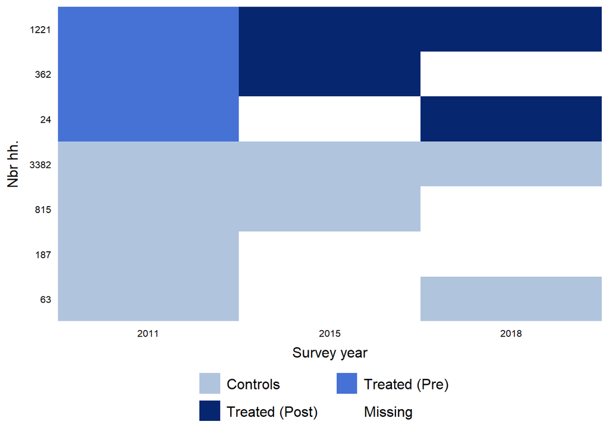

The attrited households are, on average:

- smaller in terms of size.
- have older heads.
- live in disaster-affected upazilas.
- have an Hindu household head.
- have a head who is Bengali.
- more likely to be male-headed.
- have unclear education and literacy levels.
- have fewer female members.
- have fewer teenagers.
- have fewer female teenagers.

I use R1 data to do these table

|  | **Hh. doesn’t attrited**, N = 4,690<sup>1</sup> | **Hh. attrited**, N = 1,364<sup>1</sup> | **p-value**<sup>2</sup> | **Overall**, N = 6,054<sup>1</sup> |
| --- | --- | --- | --- | --- |
| Hh. size | 4.11 (1.51) | 3.94 (1.48) | <0.001 | 4.08 (1.50) |
| Affected upazila |  |  | 0.001 |  |
| No affected | 3,445 (73%) | 941 (69%) |  | 4,386 (72%) |
| Affected | 1,245 (27%) | 423 (31%) |  | 1,668 (28%) |
| Hh. head rlgn |  |  | <0.001 |  |
| Christian | 11 (0.2%) | 2 (0.1%) |  | 13 (0.2%) |
| Hindu | 499 (11%) | 200 (15%) |  | 699 (12%) |
| Muslim | 4,180 (89%) | 1,162 (85%) |  | 5,342 (88%) |
| Hh. head ethnc |  |  | 0.049 |  |
| Bangali | 4,671 (100%) | 1,364 (100%) |  | 6,035 (100%) |
| Bihari | 3 (<0.1%) | 0 (0%) |  | 3 (<0.1%) |
| Tribal | 16 (0.3%) | 0 (0%) |  | 16 (0.3%) |
| Hh. head sex |  |  | 0.4 |  |
| female | 865 (18%) | 238 (17%) |  | 1,103 (18%) |
| male | 3,825 (82%) | 1,126 (83%) |  | 4,951 (82%) |
| Hh. head age | 43.49 (13.64) | 44.38 (14.45) | 0.044 | 43.69 (13.83) |
| Hh. head mrtl stts |  |  | 0.3 |  |
| divorced | 11 (0.2%) | 5 (0.4%) |  | 16 (0.3%) |
| married | 4,271 (91%) | 1,232 (90%) |  | 5,503 (91%) |
| separated/deserted | 33 (0.7%) | 9 (0.7%) |  | 42 (0.7%) |
| unmarried (never married) | 92 (2.0%) | 20 (1.5%) |  | 112 (1.9%) |
| widow/widower | 283 (6.0%) | 98 (7.2%) |  | 381 (6.3%) |
| Hh. head ltrc |  |  | 0.2 |  |
| can read only | 4 (<0.1%) | 1 (<0.1%) |  | 5 (<0.1%) |
| can read and write | 2,213 (47%) | 680 (50%) |  | 2,893 (48%) |
| can sign only | 1,427 (30%) | 377 (28%) |  | 1,804 (30%) |
| cannot read and write | 1,046 (22%) | 306 (22%) |  | 1,352 (22%) |
| Hh. head edctn |  |  | <0.001 |  |
| ba/bsc honors/fazil | 5 (0.1%) | 3 (0.2%) |  | 8 (0.1%) |
| ba/bsc pass/fazil | 46 (1.0%) | 17 (1.2%) |  | 63 (1.0%) |
| completed class 2 | 129 (2.8%) | 58 (4.3%) |  | 187 (3.1%) |
| completed class 3 | 134 (2.9%) | 42 (3.1%) |  | 176 (2.9%) |
| completed class 4 | 227 (4.8%) | 71 (5.2%) |  | 298 (4.9%) |
| completed class 5 | 597 (13%) | 165 (12%) |  | 762 (13%) |
| completed class 6 | 116 (2.5%) | 47 (3.4%) |  | 163 (2.7%) |
| completed class 7 | 150 (3.2%) | 51 (3.7%) |  | 201 (3.3%) |
| completed class 8 | 268 (5.7%) | 76 (5.6%) |  | 344 (5.7%) |
| completed class 9 | 305 (6.5%) | 96 (7.0%) |  | 401 (6.6%) |
| completed class i | 38 (0.8%) | 26 (1.9%) |  | 64 (1.1%) |
| completed hsc/alim | 96 (2.0%) | 24 (1.8%) |  | 120 (2.0%) |
| completed ssc/dakhil | 228 (4.9%) | 60 (4.4%) |  | 288 (4.8%) |
| diploma engineer | 1 (<0.1%) | 2 (0.1%) |  | 3 (<0.1%) |
| ma/msc and above/kamil | 21 (0.4%) | 6 (0.4%) |  | 27 (0.4%) |
| never attended school | 2,290 (49%) | 602 (44%) |  | 2,892 (48%) |
| other | 0 (0%) | 1 (<0.1%) |  | 1 (<0.1%) |
| preschool (mosque based) | 1 (<0.1%) | 0 (0%) |  | 1 (<0.1%) |
| preschool class (general) | 2 (<0.1%) | 0 (0%) |  | 2 (<0.1%) |
| reads in class i | 34 (0.7%) | 17 (1.2%) |  | 51 (0.8%) |
| ssc candidate | 2 (<0.1%) | 0 (0%) |  | 2 (<0.1%) |
| Hh. head stts |  |  |  |  |
| permanent(r1) | 4,690 (100%) | 1,364 (100%) |  | 6,054 (100%) |
| Hh. nbr fml | 2.18 (1.07) | 2.05 (1.03) | <0.001 | 2.15 (1.06) |
| Hh. nbr undrfv | 0.45 (0.62) | 0.42 (0.60) | 0.13 | 0.44 (0.61) |
| Hh. nbr yng child (5-10) | 0.55 (0.68) | 0.51 (0.66) | 0.026 | 0.54 (0.68) |
| Hh. nbr tngr (10-20) | 0.89 (0.97) | 0.77 (0.88) | <0.001 | 0.86 (0.95) |
| Hh. nbr adlts (20-65) | 2.02 (0.80) | 2.01 (0.84) | 0.7 | 2.01 (0.81) |
| Hh. nbr female undrfv | 0.23 (0.46) | 0.21 (0.45) | 0.3 | 0.22 (0.46) |
| Hh. fml yng child (5-10) | 0.27 (0.50) | 0.25 (0.50) | 0.2 | 0.27 (0.50) |
| Hh. fml tngr (10-20) | 0.45 (0.67) | 0.37 (0.61) | <0.001 | 0.44 (0.65) |
| Hh. fml adlts (20-65) | 1.13 (0.46) | 1.10 (0.46) | 0.017 | 1.12 (0.46) |

<sup>1</sup> Mean (SD); n (%)  
<sup>2</sup> Welch Two Sample t-test; Fisher’s Exact Test for Count Data; Fisher’s Exact Test for Count Data with simulated p-value (based on 2000 replicates)

[output not shown]

[output cut: 252 more lines]

```
## =======================================================================
## Note:                                       *p<0.1; **p<0.05; ***p<0.01
##                                             Author's owns computations
##
## Attrited hh. characteristics
## ==========================
##
## --------------------------
## Author's owns computations
##
## Attrited hh. characteristics
## ==========================
##
## --------------------------
## Author's owns computations
```

### Interview status

4690 hhs in round 3 have completed informations, I will take these to see how it affected. I should have at most 4690 household in R1 and R2

Here is 4603 (98.14 percent) hh for which information on the R2 is available. The remaining 87 didn’t complete the information on R2 but complete the information on R1. The 65 remaining hh migrated in r2 but complete the survey in r3 (very strange). They were able to identify in r3 were the hh migrated too (where it go). I keep them in the data.

### Hh’s head religion

### Hh head ethnicity

## Study Variables

### Socio-demographic variables

### Filtering to obtained only needed

#### Kid Sex/gender